# Regression Models Course Project

Wei Lin

October 2, 2017

Executive Summary

```r
print(?mtcars)
```

In mtcars dataset, `am == 0` stands for automatic transmission and `am == 1` stands for manual transmission.

[figure not shown]

```r
mtcars_new <- mtcars %>%
  mutate(transmission = ifelse(am == 0, 'Automatic', 'Manual')) %>%
  select(-am)
ggplot(mtcars_new) +
  geom_boxplot(aes(x = transmission, y = mpg)) +
  xlab('Cylinder') +
  ggtitle('Box Plot of MPG by Cylinder and Transmission')
```

We can fit a linear model of `mpg` by `transmission`.

```r
fit <- lm(mpg ~ transmission, mtcars_new)
coef(summary(fit))
```

```
##                     Estimate Std. Error   t value     Pr(>|t|)
## (Intercept)        17.147368   1.124603 15.247492 1.133983e-15
## transmissionManual  7.244939   1.764422  4.106127 2.850207e-04
```

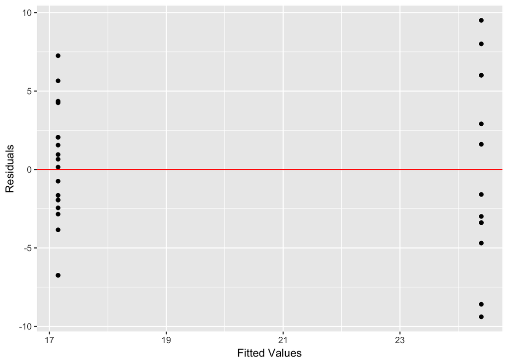

```r
ggplot() + geom_point(aes(x = fit$fitted.values, y = fit$residuals)) +
  xlab('Fitted Values') + ylab('Residuals') +
  geom_hline(aes(yintercept = 0), col = 'red')
```

Nevertheless, if we calculate the correlation matrix, we can find that the variables are highly correlated with each other in the dataset.

```r
print(cor(mtcars))
```

```
##             mpg        cyl       disp         hp        drat         wt
## mpg   1.0000000 -0.8521620 -0.8475514 -0.7761684  0.68117191 -0.8676594
## cyl  -0.8521620  1.0000000  0.9020329  0.8324475 -0.69993811  0.7824958
## disp -0.8475514  0.9020329  1.0000000  0.7909486 -0.71021393  0.8879799
## hp   -0.7761684  0.8324475  0.7909486  1.0000000 -0.44875912  0.6587479
## drat  0.6811719 -0.6999381 -0.7102139 -0.4487591  1.00000000 -0.7124406
## wt   -0.8676594  0.7824958  0.8879799  0.6587479 -0.71244065  1.0000000
## qsec  0.4186840 -0.5912421 -0.4336979 -0.7082234  0.09120476 -0.1747159
## vs    0.6640389 -0.8108118 -0.7104159 -0.7230967  0.44027846 -0.5549157
## am    0.5998324 -0.5226070 -0.5912270 -0.2432043  0.71271113 -0.6924953
## gear  0.4802848 -0.4926866 -0.5555692 -0.1257043  0.69961013 -0.5832870
## carb -0.5509251  0.5269883  0.3949769  0.7498125 -0.09078980  0.4276059
##             qsec         vs          am       gear        carb
## mpg   0.41868403  0.6640389  0.59983243  0.4802848 -0.55092507
## cyl  -0.59124207 -0.8108118 -0.52260705 -0.4926866  0.52698829
## disp -0.43369788 -0.7104159 -0.59122704 -0.5555692  0.39497686
## hp   -0.70822339 -0.7230967 -0.24320426 -0.1257043  0.74981247
## drat  0.09120476  0.4402785  0.71271113  0.6996101 -0.09078980
## wt   -0.17471588 -0.5549157 -0.69249526 -0.5832870  0.42760594
## qsec  1.00000000  0.7445354 -0.22986086 -0.2126822 -0.65624923
## vs    0.74453544  1.0000000  0.16834512  0.2060233 -0.56960714
## am   -0.22986086  0.1683451  1.00000000  0.7940588  0.05753435
## gear -0.21268223  0.2060233  0.79405876  1.0000000  0.27407284
## carb -0.65624923 -0.5696071  0.05753435  0.2740728  1.00000000
```

Therefore, this simple model does not tell the full story. If we fit a full mode, the coefficient of transmission changes and is not significant anymore.

```r
summary(lm(mpg ~ ., data = mtcars_new))
```

```
##
## Call:
## lm(formula = mpg ~ ., data = mtcars_new)
##
## Residuals:
##     Min      1Q  Median      3Q     Max
## -3.4506 -1.6044 -0.1196  1.2193  4.6271
##
## Coefficients:
##                    Estimate Std. Error t value Pr(>|t|)
## (Intercept)        12.30337   18.71788   0.657   0.5181
## cyl                -0.11144    1.04502  -0.107   0.9161
## disp                0.01334    0.01786   0.747   0.4635
## hp                 -0.02148    0.02177  -0.987   0.3350
## drat                0.78711    1.63537   0.481   0.6353
## wt                 -3.71530    1.89441  -1.961   0.0633 .
## qsec                0.82104    0.73084   1.123   0.2739
## vs                  0.31776    2.10451   0.151   0.8814
## gear                0.65541    1.49326   0.439   0.6652
## carb               -0.19942    0.82875  -0.241   0.8122
## transmissionManual  2.52023    2.05665   1.225   0.2340
## ---
## Signif. codes:  0 '***' 0.001 '**' 0.01 '*' 0.05 '.' 0.1 ' ' 1
##
## Residual standard error: 2.65 on 21 degrees of freedom
## Multiple R-squared:  0.869,  Adjusted R-squared:  0.8066
## F-statistic: 13.93 on 10 and 21 DF,  p-value: 3.793e-07
```

To find a reasonable model, we can use `step` function to find the best model for explaining `mpg`

```r
best_fit <- step(lm(mpg ~ ., data = mtcars_new), trace = 0)
summary(best_fit)
```

```
##
## Call:
## lm(formula = mpg ~ wt + qsec + transmission, data = mtcars_new)
##
## Residuals:
##     Min      1Q  Median      3Q     Max
## -3.4811 -1.5555 -0.7257  1.4110  4.6610
##
## Coefficients:
##                    Estimate Std. Error t value Pr(>|t|)
## (Intercept)          9.6178     6.9596   1.382 0.177915
## wt                  -3.9165     0.7112  -5.507 6.95e-06 ***
## qsec                 1.2259     0.2887   4.247 0.000216 ***
## transmissionManual   2.9358     1.4109   2.081 0.046716 *
## ---
## Signif. codes:  0 '***' 0.001 '**' 0.01 '*' 0.05 '.' 0.1 ' ' 1
##
## Residual standard error: 2.459 on 28 degrees of freedom
## Multiple R-squared:  0.8497, Adjusted R-squared:  0.8336
## F-statistic: 52.75 on 3 and 28 DF,  p-value: 1.21e-11
```

The residual plot is shown below. There is no clear pattern left in the residual.

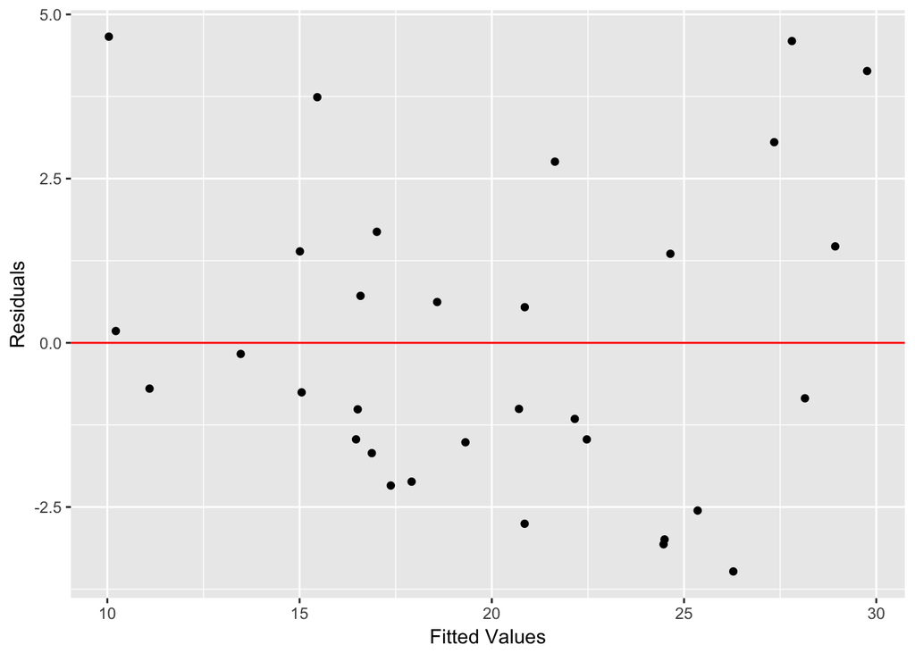

```r
ggplot() + geom_point(aes(x = best_fit$fitted.values,
                          y = best_fit$residuals)) +
  xlab('Fitted Values') + ylab('Residuals') +
  geom_hline(aes(yintercept = 0), col = 'red')
```

If we do an anova with and without transmission for the selected model, we can see the inclusion of transmission is statistically significant.

```r
anova(lm(mpg ~ wt + qsec, data = mtcars), best_fit)
```

```
## Analysis of Variance Table
##
## Model 1: mpg ~ wt + qsec
## Model 2: mpg ~ wt + qsec + transmission
##   Res.Df    RSS Df Sum of Sq      F  Pr(>F)
## 1     29 195.46
## 2     28 169.29  1    26.178 4.3298 0.04672 *
## ---
## Signif. codes:  0 '***' 0.001 '**' 0.01 '*' 0.05 '.' 0.1 ' ' 1
```